# Practice Problems 1 - SOLUTIONS

# Purpose

The goal of this set of practice problems is to practice the following skills:

- Constructing and interpreting visualizations that inform research questions of interest
- Data wrangling
- Constructing and interpreting simple linear regression models

# Directions

1. We will be using data from the `fivethirtyeight` package. Install this package by entering the `install.packages()` command in the **Console**. (Do not include the installation command in this file–your document won’t render to the required HTML file!)
2. Create a code chunk in which you load the `ggplot2`, `dplyr`, and `fivethirtyeight` packages.
3. Continue with the exercises below. You will need to create new code chunks to construct visualizations and models and write interpretations beneath. Put text responses in blockquotes as shown below:

> Response here. (The > at the start of the line starts a blockquote and makes the text larger and easier to read.)
4. Render your work for submission:
   - Click the “Render” button in the menu bar for this pane (blue arrow pointing right). This will create an HTML file containing all of the directions, code, and responses from this activity. A preview of the HTML will appear in the browser.
   - Scroll through and inspect the document to check that your work translated to the HTML format correctly.
   - Close the browser tab.
   - Go to the “Background Jobs” pane in RStudio and click the Stop button to end the rendering process.
   - Locate the rendered HTML file in the folder where this file is saved. Open the HTML to ensure that your work looks as it should (code appears, output displays, interpretations appear). Upload this HTML file to Moodle.

```r
library(ggplot2)
library(dplyr)
library(fivethirtyeight)
```

# Exercises

## Context

This cartoon by Alison Bechdel inspired the “Bechdel test” (image source):

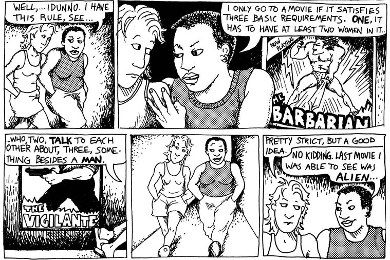

A movie passes the test if it meets the following criteria:

- there are at least 2 women-identifying characters;
- these characters talk to each other at least 1 time; and
- they talk about something other than a male-identifying character

We’ll work with the `bechdel` data within the `fivethirtyeight` package. You can enter `?bechdel` in the Console to view the codebook.

```r
# Load the data
data(bechdel)
```

## Exercise 1: Define two new variables

```r
bechdel <- bechdel %>%
    mutate(
        budget_mil = budget_2013/1000000,
        intgross_mil = intgross_2013/1000000
    )

bechdel %>%
    select(budget_mil, intgross_mil) %>%
    head(3)
## # A tibble: 3 × 2
##   budget_mil intgross_mil
##        <dbl>        <dbl>
## 1       13           42.2
## 2       45.7         41.5
## 3       20          159.
```

## Exercise 2: Get to know the data

```r
# How many films are in the dataset?
nrow(bechdel) # (or use dim)
## [1] 1794

# When was the oldest film in the dataset made?
bechdel %>%
    summarize(min(year))
## # A tibble: 1 × 1
##   `min(year)`
##         <int>
## 1        1970

# When was the most recent film in the dataset made?
bechdel %>%
    summarize(max(year))
## # A tibble: 1 × 1
##   `max(year)`
##         <int>
## 1        2013

# What is the median film budget in 2013 dollars?
bechdel %>%
    summarize(median(budget_mil))
## # A tibble: 1 × 1
##   `median(budget_mil)`
##                  <dbl>
## 1                 37.0

# What films had budgets that exceeded 300 million in 2013 dollars?
# (Just show the films and budgets, not all variables)
bechdel %>%
    filter(budget_mil > 300) %>%
    select(title, budget_mil)
## # A tibble: 3 × 2
##   title                                    budget_mil
##   <chr>                                         <dbl>
## 1 Avatar                                         461.
## 2 Pirates of the Caribbean: At World's End       337.
## 3 Shaft                                          305.

# What films were made in 1971?
# (Just show the films and year, not all variables)
bechdel %>%
    filter(year == 1971) %>%
    select(title, year)
## # A tibble: 5 × 2
##   title                                year
##   <chr>                               <int>
## 1 Escape from the Planet of the Apes   1971
## 2 Shaft                                1971
## 3 Straw Dogs                           1971
## 4 The French Connection                1971
## 5 Willy Wonka & the Chocolate Factory  1971

# What were the budget_mil and intgross_mil values for "Titanic"?
# (Just show the budget_mil and intgross_mil values)
bechdel %>%
    filter(title == "Titanic") %>%
    select(budget_mil, intgross_mil)
## # A tibble: 1 × 2
##   budget_mil intgross_mil
##        <dbl>        <dbl>
## 1       290.        3172.
```

## Exercise 3: Does it pass the Bechdel?

Discussions will vary. In general, students should point out that, overall, slightly over half of films pass the Bechdel test (are “ok” or “dubious”). Further, there should be some discussion of the films that don’t pass. For example, among the films that fail the test, most are because two women characters don’t talk to one another.

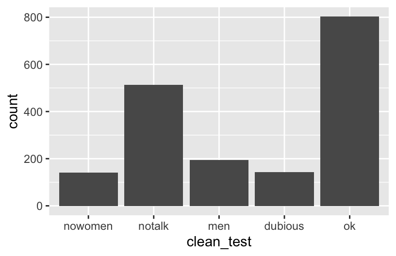

```r
ggplot(bechdel, aes(x = clean_test)) +
    geom_bar()
```

```r
bechdel %>%
    count(clean_test)
## # A tibble: 5 × 2
##   clean_test     n
##   <ord>      <int>
## 1 nowomen      141
## 2 notalk       514
## 3 men          194
## 4 dubious      142
## 5 ok           803
```

## Exercise 4: How much money did it make?

The `intgross_mil` variable records each movie’s total international gross, in millions of dollars (and adjusted to 2013).

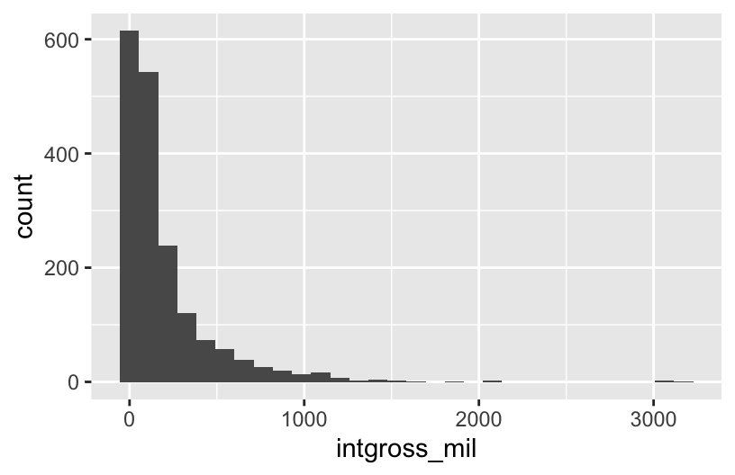

```r
# A histogram, density plot, boxplot, or other would work. You only need one!
ggplot(bechdel, aes(x = intgross_mil)) +
    geom_histogram()
```

2. The mean is pulled up by the outliers, whereas the median isn’t influenced by these outliers (it’s calculated using only the middle numbers). In this case, the mean provides a misleading calculation of what’s “typical”, thus the median is more appropriate here.

```r
bechdel %>%
    summarize(
        mean(intgross_mil, na.rm = TRUE),
        median(intgross_mil, na.rm = TRUE)
    )
## # A tibble: 1 × 2
##   `mean(intgross_mil, na.rm = TRUE)` `median(intgross_mil, na.rm = TRUE)`
##                                <dbl>                                <dbl>
## 1                               198.                                 96.2
```

3. There’s more variability in how much money movies make at the box office than in how much money is spent making movies.

```r
bechdel %>%
    summarize(
        sd(intgross_mil, na.rm = TRUE),
        sd(budget_mil, na.rm = TRUE)
    )
## # A tibble: 1 × 2
##   `sd(intgross_mil, na.rm = TRUE)` `sd(budget_mil, na.rm = TRUE)`
##                              <dbl>                          <dbl>
## 1                             284.                           54.9
```

## Exercise 5: Explaining `intgross_mil`

Next, let’s try to *explain* some of the variability in how much money films gross. To this end, we’ll focus on modeling `intgross_mil` by `budget_mil`. That is, to what extent is the money a film makes related to its budget?

1. Response = `intgross_mil`. Predictor = `budget_mil`

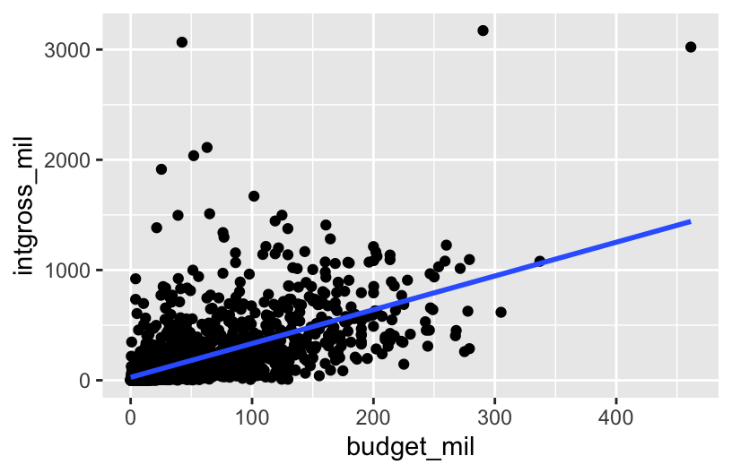

```r
ggplot(bechdel, aes(y = intgross_mil, x = budget_mil)) +
    geom_point() +
    geom_smooth(method = "lm", se = FALSE)
```

3. There’s a positive trend in the relationship between budget and gross: movies that cost more money to make tend to make more at the box office. However, there’s quite a bit of deviation from the trend. For example, there are several movies that make much more than expected.

## Exercise 6: Modeling `intgross_mil`

```r
movie_model <- lm(intgross_mil ~ budget_mil, data = bechdel)
coef(summary(movie_model))
##              Estimate Std. Error   t value      Pr(>|t|)
## (Intercept) 27.138951 7.69379045  3.527384  4.303247e-04
## budget_mil   3.063147 0.09829586 31.162528 1.574335e-170
```

2. E[intgross_mil | budget_mil] = 27.138951 + 3.063147 budget_mil (Answers may vary due to rounding)
3. For every extra 1 million dollars spent on making the movie, the expected gross increases by roughly $3.06 million.
4. It doesn’t make sense to interpret the intercept in this model. This would be the expected gross of a movie that had a $0 budget. No such movies exist in this data set.

## Exercise 7: Predictions and residuals

Answers might vary quite a bit due to rounding!

```r
# Part a
# Write a comment if there's no prediction from scratch (if they only use predict())
27.138951 + 3.063147 * 290
## [1] 915.4516
predict(movie_model, newdata = data.frame(budget_mil = 290))
##        1
## 915.4517

# Part b
3172 - 915.4516
## [1] 2256.548

# Part c
# Model drastically underestimated Titanic's gross earnings
```